# STATS506 - Assignment 3

Author

Prathibha Muthukumara Prasanna

# Problem 1

#### Problem 1a

```r
library(haven)
library(dplyr)
library(knitr)
library(kableExtra)

# Reading files from the URLs using read_xpt()
aux_i <- read_xpt("https://wwwn.cdc.gov/Nchs/Data/Nhanes/Public/2015/DataFiles/AUX_I.xpt")
demo_i <- read_xpt("https://wwwn.cdc.gov/Nchs/Data/Nhanes/Public/2015/DataFiles/DEMO_I.xpt")

# Merging the datasets using SEQN variable
merged_data <- inner_join(aux_i, demo_i, by = "SEQN")

# Creating a table to display results
kable(
  data.frame(
    File = c("AUX_I", "DEMO_I", "Merged"),
    Rows = c(nrow(aux_i), nrow(demo_i), nrow(merged_data)),
    Columns = c(ncol(aux_i), ncol(demo_i), ncol(merged_data))
  ),
  caption = "Dataset dimensions before and after merging",
  align = "lcc"
) %>%
  kable_styling(full_width = FALSE, position = "center", font_size = 14)
```

Dataset dimensions before and after merging

| File | Rows | Columns |
| --- | --- | --- |
| AUX_I | 4582 | 73 |
| DEMO_I | 9971 | 47 |
| Merged | 4582 | 119 |

```r
# Printing the dimensions of the merged dataset
cat("\nMerged dataset has", nrow(merged_data), "rows and", ncol(merged_data), "columns.\n")
```

```
Merged dataset has 4582 rows and 119 columns.
```

The SAS files have been read directly from the URLs into R as data frames. Both datasets share a unique participant ID called SEQN. Using inner_join() from dplyr, the code merges only those rows that appear in both datasets. The merged dataset represents participants who completed the audiometry examination and also have demographic information recorded. Since the audiometry file (AUX_I) includes only those who took the test, the merged dataset has the same 4,582 participants as AUX_I. The number of columns becomes 119 because the shared ID column SEQN appears in both files and is only kept once.

#### Problem 1b

```r
# Gender: RIAGENDR
merged_data <- merged_data %>%
  mutate(
    Gender = case_when(
      RIAGENDR == 1 ~ "Male",
      RIAGENDR == 2 ~ "Female",
      TRUE ~ NA_character_
    ),
    Gender = factor(Gender, levels = c("Male", "Female"))
  )

# Citizenship status: DMDCITZN
merged_data <- merged_data %>%
  mutate(
    Citizenship = case_when(
      DMDCITZN == 1 ~ "Citizen by birth/naturalization",
      DMDCITZN == 2 ~ "Not a citizen",
      DMDCITZN %in% c(7, 9) ~ NA_character_,
      TRUE ~ NA_character_
    ),
    Citizenship = factor(
      Citizenship,
      levels = c("Citizen by birth/naturalization", "Not a citizen")
    )
  )

# Number of children ≤5 years: DMDHHSZA
merged_data <- merged_data %>%
  mutate(
    NumChildren_U5 = case_when(
      DMDHHSZA == 0 ~ "0",
      DMDHHSZA == 1 ~ "1",
      DMDHHSZA == 2 ~ "2",
      DMDHHSZA == 3 ~ "3 or more",
      TRUE ~ NA_character_
    ),
    NumChildren_U5 = factor(NumChildren_U5,
                           levels = c("0", "1", "2", "3 or more"),
                           ordered = TRUE)
  )

# Annual household income: INDHHIN2
merged_data <- merged_data %>%
  mutate(
    HouseholdIncome = case_when(
      INDHHIN2 == 1  ~ "$0–$4,999",
      INDHHIN2 == 2  ~ "$5,000–$9,999",
      INDHHIN2 == 3  ~ "$10,000–$14,999",
      INDHHIN2 == 4  ~ "$15,000–$19,999",
      INDHHIN2 == 5  ~ "$20,000–$24,999",
      INDHHIN2 == 6  ~ "$25,000–$34,999",
      INDHHIN2 == 7  ~ "$35,000–$44,999",
      INDHHIN2 == 8  ~ "$45,000–$54,999",
      INDHHIN2 == 9  ~ "$55,000–$64,999",
      INDHHIN2 == 10 ~ "$65,000–$74,999",
      INDHHIN2 == 14 ~ "$75,000–$99,999",
      INDHHIN2 == 15 ~ "$100,000 and over",
      INDHHIN2 %in% c(12, 13, 77, 99) ~ NA_character_,
      TRUE ~ NA_character_
    ),
    HouseholdIncome = factor(
      HouseholdIncome,
      levels = c(
        "$0–$4,999", "$5,000–$9,999", "$10,000–$14,999",
        "$15,000–$19,999", "$20,000–$24,999", "$25,000–$34,999",
        "$35,000–$44,999", "$45,000–$54,999", "$55,000–$64,999",
        "$65,000–$74,999", "$75,000–$99,999", "$100,000 and over"
      ),
      ordered = TRUE
    )
  )
```

The four demographic variables were cleaned using the NHANES 2015–2016 codebook. Gender was coded as “Male” (n=2,176) or “Female” (n=2,406) with no missing values. Citizenship status was coded as “Citizen by birth/naturalization” (n=3,684) or “Not a citizen” (n=884), with refused and “Don’t know” responses set to missing (14 missing values). Number of children ≤5 years was ordered as “0” (n=3,463), “1” (n=737), “2” (n=317), or “3 or more” (n=65) with no missing values. Annual household income was ordered into 12 income ranges from “$0–$4,999” to “$100,000 and over”; the original data contained overlapping categories (such as “$20,000 and Over” and “Under $20,000”) that duplicated specific ranges, so these overlapping categories along with refused and “Don’t know” responses were excluded and set to missing (495 missing values total).

#### Problem 1c

```r
modeling_data <- merged_data %>%
  mutate(
    # Converting NumChildren_U5 to numeric (0, 1, 2, 3)
    NumChildren_continuous = case_when(
      NumChildren_U5 == "0" ~ 0,
      NumChildren_U5 == "1" ~ 1,
      NumChildren_U5 == "2" ~ 2,
      NumChildren_U5 == "3 or more" ~ 3,
      TRUE ~ NA_real_
    ),
    # Converting HouseholdIncome to numeric using midpoint of ranges
    Income_continuous = case_when(
      HouseholdIncome == "$0–$4,999" ~ 2.5,
      HouseholdIncome == "$5,000–$9,999" ~ 7.5,
      HouseholdIncome == "$10,000–$14,999" ~ 12.5,
      HouseholdIncome == "$15,000–$19,999" ~ 17.5,
      HouseholdIncome == "$20,000–$24,999" ~ 22.5,
      HouseholdIncome == "$25,000–$34,999" ~ 30,
      HouseholdIncome == "$35,000–$44,999" ~ 40,
      HouseholdIncome == "$45,000–$54,999" ~ 50,
      HouseholdIncome == "$55,000–$64,999" ~ 60,
      HouseholdIncome == "$65,000–$74,999" ~ 70,
      HouseholdIncome == "$75,000–$99,999" ~ 87.5,
      HouseholdIncome == "$100,000 and over" ~ 125,
      TRUE ~ NA_real_
    ),
    # Scaling income to be in units of $1000
    Income_continuous = Income_continuous / 1000
  )

# Fitting Model 1R
model_1R <- glm(AUXTWIDR ~ Gender,
                data = modeling_data,
                family = poisson(link = "log"))

# Fitting Model 2R
model_2R <- glm(AUXTWIDR ~ Gender + Citizenship + NumChildren_continuous + Income_continuous,
                data = modeling_data,
                family = poisson(link = "log"))

# Fitting Model 1L
model_1L <- glm(AUXTWIDL ~ Gender,
                data = modeling_data,
                family = poisson(link = "log"))

# Fitting Model 2L
model_2L <- glm(AUXTWIDL ~ Gender + Citizenship + NumChildren_continuous + Income_continuous,
                data = modeling_data,
                family = poisson(link = "log"))

# Function to extract IRRs and model info
extract_results <- function(model, label) {
  results <- data.frame(
    Model = label,
    Term = names(coef(model)),
    IRR = round(exp(coef(model)), 3),
    Std_Error = round(summary(model)$coefficients[, "Std. Error"], 3),
    p_value = round(summary(model)$coefficients[, "Pr(>|z|)"], 3),
    AIC = round(AIC(model), 1),
    PseudoR2 = round(1 - model$deviance / model$null.deviance, 3),
    N = nobs(model),
    row.names = NULL
  )

  # Renaming predictors
  results$Term <- gsub("GenderFemale", "Gender", results$Term)
  results$Term <- gsub("CitizenshipNot a citizen", "Citizenship", results$Term)
  results$Term <- gsub("NumChildren_continuous", "Number of Children", results$Term)
  results$Term <- gsub("Income_continuous", "Income", results$Term)
  results$Model[-1] <- ""
  return(results)
}

results_all <- rbind(
  extract_results(model_1R, "Right Ear (Gender)"),
  extract_results(model_2R, "Right Ear (Full Model)"),
  extract_results(model_1L, "Left Ear (Gender)"),
  extract_results(model_2L, "Left Ear (Full Model)")
)

results_all %>%
  kable(
    caption = "Poisson Regression Results for Tympanometric Width",
    col.names = c("Model", "Predictor", "IRR", "Std. Error", "p-value",
                  "AIC", "Pseudo R²", "N"),
    align = c("l", "l", "c", "c", "c", "c", "c", "c"),
    row.names = FALSE  # Add this line to remove row names from table
  ) %>%
  kable_styling(full_width = FALSE, position = "center", font_size = 13)
```

Poisson Regression Results for Tympanometric Width

| Model | Predictor | IRR | Std. Error | p-value | AIC | Pseudo R² | N |
| --- | --- | --- | --- | --- | --- | --- | --- |
| Right Ear (Gender) | (Intercept) | 84.317 | 0.002 | 0.000 | 96618.5 | 0.000 | 4149 |
|  | Gender | 1.009 | 0.003 | 0.006 | 96618.5 | 0.000 | 4149 |
| Right Ear (Full Model) | (Intercept) | 86.725 | 0.004 | 0.000 | 84868.2 | 0.006 | 3705 |
|  | Gender | 1.015 | 0.004 | 0.000 | 84868.2 | 0.006 | 3705 |
|  | Citizenship | 1.046 | 0.005 | 0.000 | 84868.2 | 0.006 | 3705 |
|  | Number of Children | 0.994 | 0.003 | 0.033 | 84868.2 | 0.006 | 3705 |
|  | Income | 0.487 | 0.046 | 0.000 | 84868.2 | 0.006 | 3705 |
| Left Ear (Gender) | (Intercept) | 84.758 | 0.002 | 0.000 | 98685.1 | 0.000 | 4103 |
|  | Gender | 1.013 | 0.003 | 0.000 | 98685.1 | 0.000 | 4103 |
| Left Ear (Full Model) | (Intercept) | 86.818 | 0.004 | 0.000 | 86619.2 | 0.003 | 3665 |
|  | Gender | 1.019 | 0.004 | 0.000 | 86619.2 | 0.003 | 3665 |
|  | Citizenship | 1.022 | 0.005 | 0.000 | 86619.2 | 0.003 | 3665 |
|  | Number of Children | 0.983 | 0.003 | 0.000 | 86619.2 | 0.003 | 3665 |
|  | Income | 0.612 | 0.046 | 0.000 | 86619.2 | 0.003 | 3665 |

#### Problem 1d

```r
# Extracting the coefficient summary for the gender variable
summary_2L <- summary(model_2L)
gender_coef <- summary_2L$coefficients["GenderFemale", ]

# Displaying Wald test results
cat("Coefficient (log scale):", round(gender_coef["Estimate"], 4), "\n")
```

```
Coefficient (log scale): 0.0188
```

```r
cat("Standard Error:", round(gender_coef["Std. Error"], 4), "\n")
```

```
Standard Error: 0.0036
```

```r
cat("Z-statistic:", round(gender_coef["z value"], 4), "\n")
```

```
Z-statistic: 5.2152
```

```r
cat("P-value:", round(gender_coef["Pr(>|z|)"], 4), "\n")
```

```
P-value: 0
```

```r
cat("IRR (Female vs Male):", round(exp(gender_coef["Estimate"]), 4), "\n\n")
```

```
IRR (Female vs Male): 1.0189
```

```r
# Creating prediction data for a typical male and female
pred_data <- data.frame(
  Gender = factor(c("Male", "Female"), levels = c("Male", "Female")),
  Citizenship = factor(rep("Citizen by birth/naturalization", 2),
                      levels = c("Citizen by birth/naturalization", "Not a citizen")),
  NumChildren_continuous = rep(mean(modeling_data$NumChildren_continuous, na.rm = TRUE), 2),
  Income_continuous = rep(mean(modeling_data$Income_continuous, na.rm = TRUE), 2)
)

# Getting predicted values
predictions <- predict(model_2L, newdata = pred_data, type = "response", se.fit = TRUE)

pred_male <- predictions$fit[1]
pred_female <- predictions$fit[2]
se_male <- predictions$se.fit[1]
se_female <- predictions$se.fit[2]

# Calculating difference and test statistic
diff <- pred_female - pred_male
se_diff <- sqrt(se_male^2 + se_female^2)
z_stat <- diff / se_diff
p_value <- 2 * pnorm(-abs(z_stat))

# Displaying predicted values test results
cat("Predicted width for males:", round(pred_male, 3), "\n")
```

```
Predicted width for males: 83.861
```

```r
cat("Predicted width for females:", round(pred_female, 3), "\n")
```

```
Predicted width for females: 85.45
```

```r
cat("Difference (Female - Male):", round(diff, 3), "\n")
```

```
Difference (Female - Male): 1.589
```

```r
cat("SE of difference:", round(se_diff, 3), "\n")
```

```
SE of difference: 0.322
```

```r
cat("Z-statistic:", round(z_stat, 4), "\n")
```

```
Z-statistic: 4.9382
```

```r
cat("P-value:", round(p_value, 4), "\n")
```

```
P-value: 0
```

The Wald test examines whether the gender coefficient is significantly different from zero. The IRR for females compared to males is 1.019, indicating that females have approximately 1.9% higher tympanometric width than males, holding other variables constant. With a z-statistic of 5.22 and p-value < 0.001, there is strong statistical evidence of a difference in IRR between males and females. At mean values of number of children and income (and citizenship), the predicted tympanometric width for males is 83.86 compared to 85.45 for females, a difference of 1.59 units. The z-test gives a z-statistic of 4.94 with p-value < 0.001, providing strong evidence that predicted tympanometric width differs significantly between males and females.

# Problem 2

#### Problem 2a

```r
library(DBI)
library(RSQLite)
library(microbenchmark)
sakila <- dbConnect(SQLite(), "~/Downloads/sakila_master.db")

customer <- dbGetQuery(sakila, "SELECT * FROM customer")

# Using R to calculate statistics by store
# Convert active to numeric
customer$active <- as.numeric(customer$active)

store_counts <- table(customer$store_id)
active_counts <- tapply(customer$active, customer$store_id, sum)
percent_active <- round((active_counts / store_counts) * 100, 2)

result_r <- data.frame(
  store_id = names(store_counts),
  total_customers = as.numeric(store_counts),
  active_customers = as.numeric(active_counts),
  percent_active = as.numeric(percent_active)
)

result_r
```

```
  store_id total_customers active_customers percent_active
1        1             326              318          97.55
2        2             273              266          97.44
```

The customer table was extracted from the database using SQL, then R operations were used to calculate the statistics. The active column was converted from character to numeric. Using `table()` to count customers per store and `tapply()` to sum active customers by store: Store 1 has 326 total customers with 318 active (97.55% active rate) and Store 2 has 273 total customers with 266 active (97.44% active rate)

```r
result_sql <- dbGetQuery(sakila, "
SELECT
  store_id,
  COUNT(*) AS total_customers,
  SUM(active) AS active_customers,
  ROUND(SUM(active) * 100.0 / COUNT(*), 2) AS percent_active
FROM customer
GROUP BY store_id
")
result_sql
```

```
  store_id total_customers active_customers percent_active
1        1             326              318          97.55
2        2             273              266          97.44
```

The same results were obtained using a single SQL query that performs all calculations directly in the database. The query uses `COUNT(*)` for total customers, `SUM(active)` for active customers, and calculates the percentage in one step using `GROUP BY store_id`. This approach produces identical results: Store 1 with 326 customers (97.55% active) and Store 2 with 273 customers (97.44% active).

```r
benchmark_results <- microbenchmark(
  SQL_plus_R = {
    customer <- dbGetQuery(sakila, "SELECT * FROM customer")
    customer$active <- as.numeric(customer$active)
    store_counts <- table(customer$store_id)
    active_counts <- tapply(customer$active, customer$store_id, sum)
    percent_active <- round((active_counts / store_counts) * 100, 2)
    data.frame(
      store_id = names(store_counts),
      total_customers = as.numeric(store_counts),
      active_customers = as.numeric(active_counts),
      percent_active = as.numeric(percent_active)
    )
  },

  Single_SQL = {
    dbGetQuery(sakila, "
      SELECT
        store_id,
        COUNT(*) AS total_customers,
        SUM(active) AS active_customers,
        ROUND(SUM(active) * 100.0 / COUNT(*), 2) AS percent_active
      FROM customer
      GROUP BY store_id
    ")
  },

  times = 100
)

print(benchmark_results)
```

```
Unit: microseconds
       expr     min       lq     mean   median      uq      max neval
 SQL_plus_R 769.611 790.3775 839.3200 835.9285 876.990 1081.088   100
 Single_SQL 145.345 156.5585 167.5026 167.2595 176.013  228.575   100
```

#### Problem 2b

```r
staff <- dbGetQuery(sakila, "SELECT * FROM staff")
address <- dbGetQuery(sakila, "SELECT * FROM address")
city <- dbGetQuery(sakila, "SELECT * FROM city")
country <- dbGetQuery(sakila, "SELECT * FROM country")

staff_address <- merge(staff, address, by = "address_id", all.x = TRUE)
staff_city <- merge(staff_address, city, by = "city_id", all.x = TRUE)
staff_country <- merge(staff_city, country, by = "country_id", all.x = TRUE)

result_r <- staff_country[, c("first_name", "last_name", "country")]

result_r
```

```
  first_name last_name   country
1        Jon  Stephens Australia
2       Mike   Hillyer    Canada
```

Four tables (staff, address, city, country) were extracted from the database and merged in R using merge(). The staff table was joined with address by address_id, then with city by city_id, and finally with country by country_id. The results show there are 2 staff members: Jon Stephens from Australia and Mike Hillyer from Canada.

```r
result_sql <- dbGetQuery(sakila, "
SELECT
  s.first_name,
  s.last_name,
  co.country
FROM staff AS s
LEFT JOIN address AS a ON s.address_id = a.address_id
LEFT JOIN city AS ci ON a.city_id = ci.city_id
LEFT JOIN country AS co ON ci.country_id = co.country_id
")

result_sql
```

```
  first_name last_name   country
1       Mike   Hillyer    Canada
2        Jon  Stephens Australia
```

The same results were obtained using a single SQL query with three LEFT JOINs to connect staff → address → city → country. This returns the same 2 staff members with their names and countries.

```r
benchmark_results <- microbenchmark(
  SQL_plus_R = {
    staff <- dbGetQuery(sakila, "SELECT * FROM staff")
    address <- dbGetQuery(sakila, "SELECT * FROM address")
    city <- dbGetQuery(sakila, "SELECT * FROM city")
    country <- dbGetQuery(sakila, "SELECT * FROM country")

    staff_address <- merge(staff, address, by = "address_id", all.x = TRUE)
    staff_city <- merge(staff_address, city, by = "city_id", all.x = TRUE)
    staff_country <- merge(staff_city, country, by = "country_id", all.x = TRUE)

    staff_country[, c("first_name", "last_name", "country")]
  },

  Single_SQL = {
    dbGetQuery(sakila, "
      SELECT
        s.first_name,
        s.last_name,
        co.country
      FROM staff AS s
      LEFT JOIN address AS a ON s.address_id = a.address_id
      LEFT JOIN city AS ci ON a.city_id = ci.city_id
      LEFT JOIN country AS co ON ci.country_id = co.country_id
    ")
  },

  times = 100
)

print(benchmark_results)
```

```
Unit: microseconds
       expr      min        lq      mean   median        uq      max neval
 SQL_plus_R 1708.101 1791.4130 1899.1249 1840.141 1880.9570 3579.833   100
 Single_SQL   91.881   98.4205  106.9825  106.805  112.3605  141.204   100
```

```r
film <- dbGetQuery(sakila, "SELECT * FROM film")
inventory <- dbGetQuery(sakila, "SELECT * FROM inventory")
rental <- dbGetQuery(sakila, "SELECT * FROM rental")
payment <- dbGetQuery(sakila, "SELECT * FROM payment")

rental_inventory <- merge(rental, inventory, by = "inventory_id", all.x = TRUE)
rental_film <- merge(rental_inventory, film, by = "film_id", all.x = TRUE)
rental_payment <- merge(rental_film, payment, by = "rental_id", all.x = TRUE)

max_amount <- max(rental_payment$amount, na.rm = TRUE)

result_r <- rental_payment[rental_payment$amount == max_amount, c("title", "amount")]
result_r <- unique(result_r)

cat("Maximum rental amount: $", max_amount, "\n\n", sep = "")
```

```
Maximum rental amount: $11.99
```

```r
result_r
```

```
                      title amount
106               SHOW LORD  11.99
2165       VIRTUAL SPOILERS  11.99
3971    MIDSUMMER GROUNDHOG  11.99
4381            MINE TITANS  11.99
8828        SCORPION APOLLO  11.99
11475           TIES HUNGER  11.99
14755        STING PERSONAL  11.99
14759 FLINTSTONES HAPPINESS  11.99
15411             TRAP GUYS  11.99
```

```r
result_sql <- dbGetQuery(sakila, "
SELECT DISTINCT f.title, p.amount
FROM film AS f
JOIN inventory AS i ON f.film_id = i.film_id
JOIN rental AS r ON i.inventory_id = r.inventory_id
JOIN payment AS p ON r.rental_id = p.rental_id
WHERE p.amount = (SELECT MAX(amount) FROM payment)
ORDER BY f.title
")

result_sql
```

```
                  title amount
1 FLINTSTONES HAPPINESS  11.99
2   MIDSUMMER GROUNDHOG  11.99
3           MINE TITANS  11.99
4       SCORPION APOLLO  11.99
5             SHOW LORD  11.99
6        STING PERSONAL  11.99
7           TIES HUNGER  11.99
8             TRAP GUYS  11.99
9      VIRTUAL SPOILERS  11.99
```

```r
benchmark_results <- microbenchmark(
  SQL_plus_R = {
    film <- dbGetQuery(sakila, "SELECT * FROM film")
    inventory <- dbGetQuery(sakila, "SELECT * FROM inventory")
    rental <- dbGetQuery(sakila, "SELECT * FROM rental")
    payment <- dbGetQuery(sakila, "SELECT * FROM payment")

    rental_inventory <- merge(rental, inventory, by = "inventory_id", all.x = TRUE)
    rental_film <- merge(rental_inventory, film, by = "film_id", all.x = TRUE)
    rental_payment <- merge(rental_film, payment, by = "rental_id", all.x = TRUE)

    max_amount <- max(rental_payment$amount, na.rm = TRUE)
    result <- rental_payment[rental_payment$amount == max_amount, c("title", "amount")]
    unique(result)
  },

  Single_SQL = {
    dbGetQuery(sakila, "
      SELECT DISTINCT f.title, p.amount
      FROM film AS f
      JOIN inventory AS i ON f.film_id = i.film_id
      JOIN rental AS r ON i.inventory_id = r.inventory_id
      JOIN payment AS p ON r.rental_id = p.rental_id
      WHERE p.amount = (SELECT MAX(amount) FROM payment)
      ORDER BY f.title
    ")
  },

  times = 100
)

print(benchmark_results)
```

```
Unit: microseconds
       expr       min         lq      mean    median        uq        max neval
 SQL_plus_R 50977.842 54214.1360 61663.890 57667.463 64016.314 123652.023   100
 Single_SQL   815.408   889.7615  1099.219  1052.777  1255.338   2549.585   100
```

# Problem 3

#### Problem 3a

```r
australia <- read.csv("/Users/prathi/Downloads/au-500.csv", stringsAsFactors = FALSE)

is_dot_com <- grepl("\\.com$|\\.com/$", australia$web)

# Counting how many are .com
com_count <- sum(is_dot_com)
total_count <- nrow(australia)

# Calculating percentage
com_percentage <- round((com_count / total_count) * 100, 2)

cat("Total websites:", total_count, "\n")
```

```
Total websites: 500
```

```r
cat(".com websites:", com_count, "\n")
```

```
.com websites: 0
```

```r
cat("Percentage:", com_percentage, "%\n")
```

```
Percentage: 0 %
```

```r
australia$ending <- sub(".*(\\.[a-z\\.]+)$", "\\1", australia$web)
table(australia$ending)
```

```
.au
500
```

```r
head(australia$web, 10)
```

```
 [1] "http://www.brandtjonathanfesq.com.au"
 [2] "http://www.landrumtemporaryservices.com.au"
 [3] "http://www.inabinetmacreesq.com.au"
 [4] "http://www.morrisdowningsherred.com.au"
 [5] "http://www.bueltdavidlesq.com.au"
 [6] "http://www.artesianicecoldstorageco.com.au"
 [7] "http://www.midwayhotel.com.au"
 [8] "http://www.selsorrobertjesq.com.au"
 [9] "http://www.vincentjpettico.com.au"
[10] "http://www.prentisspaulfesq.com.au"
```

```r
# Since all are Australian domains ending in .au
is_com_au <- grepl("\\.com\\.au", australia$web)

com_count <- sum(is_com_au)
total_count <- nrow(australia)
com_percentage <- round((com_count / total_count) * 100, 2)

cat("Total websites:", total_count, "\n")
```

```
Total websites: 500
```

```r
cat(".com.au websites:", com_count, "\n")
```

```
.com.au websites: 500
```

```r
cat("Percentage:", com_percentage, "%\n")
```

```
Percentage: 100 %
```

```r
# Verifying by checking for other types like .net.au, .org.au
net_count <- sum(grepl("\\.net\\.au", australia$web))
org_count <- sum(grepl("\\.org\\.au", australia$web))

cat("\n.net.au websites:", net_count, "\n")
```

```
.net.au websites: 0
```

```r
cat(".org.au websites:", org_count, "\n")
```

```
.org.au websites: 0
```

All 500 websites in the Australian dataset use the .com.au domain extension. There are no .com, .org.au, or other alternative domain types in this dataset. Therefore, 0% of the websites are .com’s.

#### Problem 3b

```r
# Extracting the domain name (everything after the @)
australia$email_domain <- sub(".*@", "", australia$email)

domain_counts <- table(australia$email_domain)

# Sorting by frequency (descending)
domain_counts_sorted <- sort(domain_counts, decreasing = TRUE)

# Finding the most common domain
most_common_domain <- names(domain_counts_sorted)[1]
most_common_count <- domain_counts_sorted[1]

cat("\nMost common email domain:", most_common_domain, "\n")
```

```
Most common email domain: hotmail.com
```

```r
cat("Number of occurrences:", most_common_count, "\n")
```

```
Number of occurrences: 114
```

```r
cat("Percentage:", round((most_common_count / nrow(australia)) * 100, 2), "%\n")
```

```
Percentage: 22.8 %
```

```r
top_domains <- data.frame(
  Domain = names(head(domain_counts_sorted, 10)),
  Count = as.numeric(head(domain_counts_sorted, 10)),
  Percentage = round((as.numeric(head(domain_counts_sorted, 10)) / nrow(australia)) * 100, 2)
)

kable(top_domains,
      caption = "Top 10 Most Common Email Domains",
      col.names = c("Email Domain", "Count", "Percentage (%)"),
      align = c("l", "r", "r"),
      row.names = FALSE) %>%
  kable_styling(full_width = FALSE, position = "center")
```

Top 10 Most Common Email Domains

| Email Domain | Count | Percentage (%) |
| --- | --- | --- |
| hotmail.com | 114 | 22.8 |
| gmail.com | 102 | 20.4 |
| yahoo.com | 84 | 16.8 |
| agar.net.au | 1 | 0.2 |
| agney.net.au | 1 | 0.2 |
| ahlborn.com.au | 1 | 0.2 |
| albrough.com.au | 1 | 0.2 |
| alerte.com.au | 1 | 0.2 |
| amedro.net.au | 1 | 0.2 |
| andrion.com.au | 1 | 0.2 |

The most common email domain is hotmail.com with 114 occurrences (22.8%).

#### Problem 3c

```r
# Checking for any character that is NOT a letter, comma, or space
has_special_char <- grepl("[^A-Za-z, ]", australia$company_name)

count_with_special <- sum(has_special_char)
total_companies <- nrow(australia)
proportion_special <- round((count_with_special / total_companies) * 100, 2)


cat("Companies with non-alphabetic characters:", count_with_special, "\n")
```

```
Companies with non-alphabetic characters: 45
```

```r
cat("Total companies:", total_companies, "\n")
```

```
Total companies: 500
```

```r
cat("Proportion:", proportion_special, "%\n\n")
```

```
Proportion: 9 %
```

```r
# Checking for any character that is NOT a letter, comma, space, or ampersand
has_special_no_amp <- grepl("[^A-Za-z, &]", australia$company_name)

count_with_special_no_amp <- sum(has_special_no_amp)
proportion_special_no_amp <- round((count_with_special_no_amp / total_companies) * 100, 2)

cat("Companies with non-alphabetic characters:", count_with_special_no_amp, "\n")
```

```
Companies with non-alphabetic characters: 4
```

```r
cat("Total companies:", total_companies, "\n")
```

```
Total companies: 500
```

```r
cat("Proportion:", proportion_special_no_amp, "%\n\n")
```

```
Proportion: 0.8 %
```

```r
has_special_not_amp <- has_special_char & !has_special_no_amp
cat("Examples with ampersands (but no other special characters):\n")
```

```
Examples with ampersands (but no other special characters):
```

```r
head(australia$company_name[has_special_not_amp], 10)
```

```
 [1] "Morris Downing & Sherred"       "Artesian Ice & Cold Storage Co"
 [3] "Vincent J Petti & Co"           "N Amer Plast & Chemls Co Inc"
 [5] "Joiner & Goudeau Law Offices"   "A & A Custom Rubber Stamps"
 [7] "A B C Pattern & Foundry Co"     "Low Country Kitchen & Bath"
 [9] "Walker & Brehn Pa"              "Components & Equipment Co"
```

```r
summary_table <- data.frame(
  Condition = c("Excluding commas & whitespace",
                "Also excluding ampersands"),
  Count = c(count_with_special, count_with_special_no_amp),
  Proportion = c(proportion_special, proportion_special_no_amp)
)

kable(summary_table,
      caption = "Proportion of Company Names with Non-Alphabetic Characters",
      col.names = c("Exclusion Condition", "Count", "Proportion (%)"),
      align = c("l", "r", "r"),
      row.names = FALSE) %>%
  kable_styling(full_width = FALSE, position = "center")
```

Proportion of Company Names with Non-Alphabetic Characters

| Exclusion Condition | Count | Proportion (%) |
| --- | --- | --- |
| Excluding commas & whitespace | 45 | 9.0 |
| Also excluding ampersands | 4 | 0.8 |

Out of 500 companies, 45 have company names that contain at least one non-alphabetic character (excluding commas and whitespace). These special characters include ampersands, hyphens, periods, apostrophes, and other punctuation marks. Upon excluding ampersands from consideration, only 4 companies (0.8%) have names with other non-alphabetic characters.

#### Problem 3d

```r
format_to_cell <- function(phone) {
  phone_clean <- gsub("-", "", phone)

  # Reformatting to cell phone style: 1234-567-890
  phone_formatted <- paste0(
    substr(phone_clean, 1, 4), "-",
    substr(phone_clean, 5, 7), "-",
    substr(phone_clean, 8, 10)
  )

  return(phone_formatted)
}

# Reformatting phone1 (landlines) to cell phone format
australia$phone1 <- format_to_cell(australia$phone1)

# phone2 is already in cell format, so no change needed
australia$phone2 <- format_to_cell(australia$phone2)

cat("\n\nReformatted phone numbers (all in cell phone format):\n")
```

```
Reformatted phone numbers (all in cell phone format):
```

```r
cat("\nFirst 10 from phone1:\n")
```

```
First 10 from phone1:
```

```r
head(australia$phone1, 10)
```

```
 [1] "0381-749-123" "0799-973-366" "0855-589-019" "0260-444-682" "0214-556-085"
 [6] "0878-681-355" "0865-228-931" "0252-269-402" "0731-849-989" "0868-904-661"
```

```r
cat("\nFirst 10 from phone2:\n")
```

```
First 10 from phone2:
```

```r
head(australia$phone2, 10)
```

```
 [1] "0458-665-290" "0497-622-620" "0427-885-282" "0443-795-912" "0453-666-885"
 [6] "0451-966-921" "0427-991-688" "0415-961-606" "0411-732-965" "0461-862-457"
```

All phone numbers were reformatted to the cell phone format. The landline phone numbers in phone1 were converted from the format ‘02-1234-5678’ to ‘0212-345-678’ by removing all dashes and reinserting them in the cell phone pattern. The phone2 column already used the cell phone format, so it remained unchanged.

#### Problem 3e

```r
# Extracting apartment numbers
# Pattern 1: Numbers after # (e.g., "534 Schoenborn St #51")
# Pattern 2: Just numbers at the very end (e.g., "22222 Acoma St")

# Checking if there's a # in the address
has_hash <- grepl("#", australia$address)

# For addresses with #, extract number after #
apt_with_hash <- sub(".*#(\\d+).*", "\\1", australia$address[has_hash])

# For addresses without #, extract number at the end
apt_no_hash <- sub(".*\\s(\\d+)$", "\\1", australia$address[!has_hash])
australia$apt_number <- NA
australia$apt_number[has_hash] <- as.numeric(apt_with_hash)
australia$apt_number[!has_hash] <- as.numeric(apt_no_hash)

# Filtering out addresses where extraction failed or no apartment number exists
has_valid_apt <- !is.na(australia$apt_number) & australia$apt_number > 0

cat("\n\nNumber of addresses with apartment numbers:", sum(has_valid_apt), "\n")
```

```
Number of addresses with apartment numbers: 130
```

```r
examples <- head(which(has_valid_apt), 15)
for(i in examples) {
  cat(australia$address[i], "-> Apt #", australia$apt_number[i], "\n")
}
```

```
534 Schoenborn St #51 -> Apt # 51
60562 Ky Rt 321 -> Apt # 321
68828 S 32nd St #6 -> Apt # 6
387 Airway Cir #62 -> Apt # 62
4 Brookcrest Dr #7786 -> Apt # 7786
50968 Kurtz St #45 -> Apt # 45
71585 S Ayon Ave #9 -> Apt # 9
8 Old County Rd #3 -> Apt # 3
6149 Kapiolani Blvd #6 -> Apt # 6
95431 34th Ave #62 -> Apt # 62
1585 Salem Church Rd #59 -> Apt # 59
86 Worth St #272 -> Apt # 272
15 Campville Rd #191 -> Apt # 191
4 S Main St #285 -> Apt # 285
1255 W Passaic St #1553 -> Apt # 1553
```

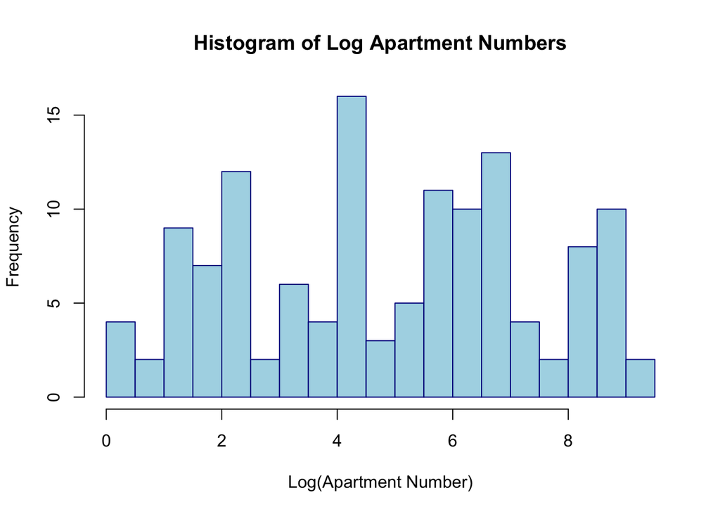

```r
# Calculating log of apartment numbers
australia$log_apt <- log(australia$apt_number)

# Creating histogram
hist(australia$log_apt[has_valid_apt],
     main = "Histogram of Log Apartment Numbers",
     xlab = "Log(Apartment Number)",
     ylab = "Frequency",
     col = "lightblue",
     border = "darkblue",
     breaks = 20)
```

Apartment numbers were extracted from addresses by identifying numbers that appeared after a “#” symbol or at the end of the address string. The natural logarithm was applied to these apartment numbers. The histogram shows that log apartment numbers are fairly evenly distributed across the range, with a peak around log values of 4. This indicates apartment numbers in the dataset vary widely, from single digits to several thousand.

#### Problem 3f

```r
table(substr(australia$apt_number, 1, 1))
```

```
 1  2  3  4  5  6  7  8  9
12 19 16 13 14 18  8 11 19
```

The apartment numbers show a relatively uniform distribution, rather than the decreasing distribution expected by Benford’s Law. This uniform distribution suggests the data does not follow Benford’s Law and would not pass as real data.

# Attribution of Sources

Problem 1: 1. https://haven.tidyverse.org/reference/read_xpt.html - haven package 2. https://www.geeksforgeeks.org/r-language/how-to-merge-data-in-r-using-r-merge-dplyr-or-data-table/ - merging datasets 3. https://dplyr.tidyverse.org/reference/case_when.html - case_when() function 4. https://r4ds.had.co.nz/factors.html - creating factors in R 5. https://stats.stackexchange.com/questions/46345/how-to-calculate-goodness-of-fit-in-glm-r - Pseudo R-squared 6. https://www.geeksforgeeks.org/r-machine-learning/how-to-perform-a-wald-test-in-r/ - Wald test

Problem 2: Didn’t use many resources since I know SQL

Problem 3: 1. https://stat.ethz.ch/R-manual/R-devel/library/base/html/grep.html - grepl() 2. https://r4ds.hadley.nz/regexps.html - regex 3. https://r4ds.had.co.nz/strings.html#matching-patterns-with-regular-expressions - regex 4. https://stackoverflow.com/questions/11936339/replace-specific-characters-within-strings - gsub() 5. https://www.r-bloggers.com/2020/08/benfords-law-applying-to-existing-data/ - Benford’s Law

# Github Repository

https://github.com/prathii7/Computational-Methods-and-Tools-in-Statistics